# Final Project

Submitted on: 12-13-2020

### Load Packages

```r
library(rvest)
library(tidyverse)
library(genius)
library(tidytext)
library(qdap)
library(dplyr)
library (gridExtra)
```

### Data Scraping

```r
# read webpage for Grammy Awards
webpage <- read_html("https://en.wikipedia.org/wiki/Grammy_Award_for_Record_of_the_Year")


XPATH80 <- '/html/body/div[3]/div[3]/div[5]/div[1]/table[5]'


table_1980 <-
  webpage %>%
  html_nodes(xpath = XPATH80) %>%
  html_table(fill = TRUE)

D1980 <- table_1980[[1]]

XPATH90<- '/html/body/div[3]/div[3]/div[5]/div[1]/table[6]'

table_1990 <-
  webpage %>%
  html_nodes(xpath = XPATH90) %>%
  html_table(fill = TRUE)

D1990 <-table_1990 [[1]]


XPATH00 <- '/html/body/div[3]/div[3]/div[5]/div[1]/table[7]'

table_2000 <-
  webpage %>%
  html_nodes(xpath = XPATH00) %>%
  html_table(fill = TRUE)

D2000 <- table_2000 [[1]]


XPATH10 <-'/html/body/div[3]/div[3]/div[5]/div[1]/table[8]'

table_2010 <-
  webpage %>%
  html_nodes(xpath = XPATH10) %>%
  html_table(fill = TRUE)

D2010 <- table_2010[[1]]
```

### Renaming the variable in each data table

```r
  D1980 <-
  D1980 %>%
  rename(year = `Year[I]`,
         track = Record,
         artist = `Artist(s)`)

  D1990 <-
  D1990 %>%
  rename(year = `Year[I]`,
         track = Record,
         artist = `Artist(s)`)

  D2000 <-
  D2000 %>%
  rename(year = `Year[I]`,
         track = Record,
         artist = `Artist(s)`)

  D2010 <-
  D2010 %>%
  rename(year = `Year[I]`,
         track = Record,
         artist = `Artist(s)`)
```

### Removing the Production Team Variable in each table

```r
D1980 <- D1980 [ , -4]

D1990 <- D1990 [ , -4]

D2000 <- D2000 [ , -4]

D2010 <- D2010 [ , -4]
```

### Removing bracketed numbers in the Year Column

```r
D1980 <-
D1980 %>%
 mutate(year=gsub(pattern ='(\\[\\d+\\])', replacement = "", x = year))

D1990 <-
D1990 %>%
 mutate(year=gsub(pattern ='(\\[\\d+\\])', replacement = "", x = year))

D2000 <-
D2000 %>%
 mutate(year=gsub(pattern ='(\\[\\d+\\])', replacement = "", x = year))

D2010 <-
D2010 %>%
 mutate(year=gsub(pattern ='(\\[\\d+\\])', replacement = "", x = year))
```

### Removing the NA cases in each data table

```r
D1980 <-
  D1980 %>%
  na.omit()

D1990 <-
  D1990 %>%
  na.omit()

D2000 <-
  D2000 %>%
  na.omit()

D2010 <-
  D2010 %>%
  na.omit()
```

### Creating the decade variable

```r
D1980 <-
  D1980 %>%
  mutate (decade = '1980')

D1990 <-
  D1990 %>%
  mutate (decade = '1990')

D2000 <-
  D2000 %>%
  mutate (decade = '2000')

D2010 <-
  D2010%>%
  mutate (decade = '2010')
```

### Joining the Tables

```r
JoinOne <-
  D1980 %>%
  full_join(D1990)

JoinTwo <-
  JoinOne %>%
  full_join(D2000)

FinalizedTable <-
  JoinTwo %>%
  full_join(D2010)
```

### Adding the lyrics

```r
Lyrics<- FinalizedTable %>%
  add_genius(artist, track, type = "lyrics")
```

### Getting the verse words by using count and tidytext

```r
Lyrics <-
  Lyrics %>%
  unnest_tokens(word, lyric)
```

### Graph 1

```r
LyricsGraph1 <-
  Lyrics %>%
  group_by (decade, track) %>%
  count( word, track) %>%
  summarise (words_per_song = sum(n))
```

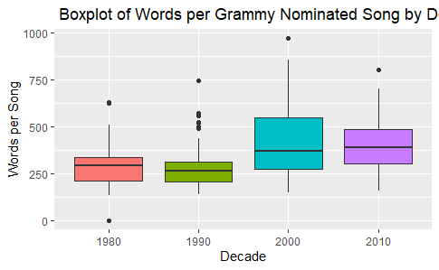

```r
ggplot(LyricsGraph1) +
 aes(x = decade, y = words_per_song, fill = decade) +
 geom_boxplot() +
  labs(title = " Boxplot of Words per Grammy Nominated Song by Decade" ,x = "Decade" , y = "Words per Song") +
 scale_fill_hue() +
 theme_grey() +
  theme(legend.position = "none")
```

### From the graph above, we can see that the minimum words per song occurs in the decade 1980 and the maximum occurs in the decade 2000. The decade with the most variability is 2000 and the decade with the least varaibility is 1990, which can be shown by estimating the range of data by taking the highest words per song value and the lowest words per song value and subtracting them and then dividing the range by 4.

### Getting rid of the stop words

```r
FilteredLyrics <- Lyrics %>%
  anti_join(stop_words)
```

### Filtering out words missed by stop words.

```r
FilteredLyrics <-
   FilteredLyrics %>%
  filter (word != "yeah" & word!= "da" & word!= "du"& word != "ya" & word != "ooh" & word != "gonna" & word != "na" & word != "uh" & word != "la" & word != "hol")
```